# Lending Club Capstone Final

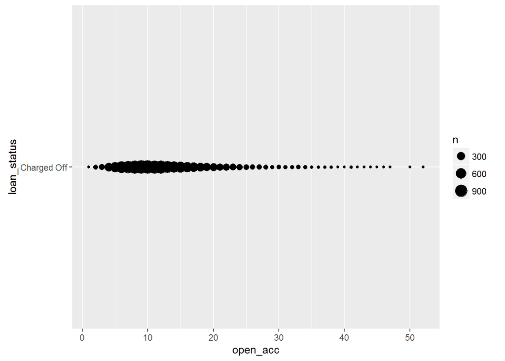

```r
#open accounts open arent unusually high either, it is healthy to have 5-20 credit #accounts open for a typical household between store cards, credit cards and other #likes like auto, student, mortgage

open_accounts <- subset(LC, select = c ("loan_status", "open_acc"))
open_accounts_2 <- subset(open_accounts, loan_status == "Charged Off")
ggplot(open_accounts_2, aes(x= open_acc, y= loan_status) ) + geom_count()
```

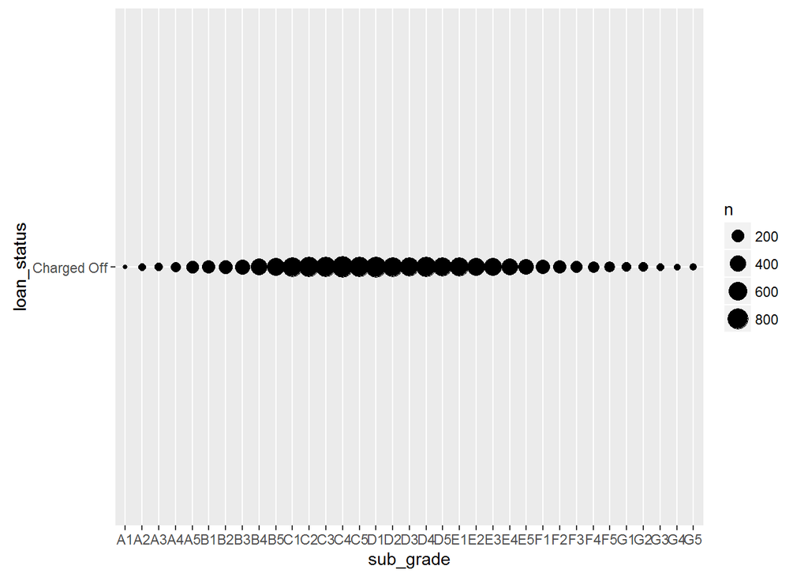

```r
#grade looks like a normal bell curve and not because LC allowed many high risk #profiles according to their algorithms

grade <- subset(LC, select = c ("loan_status", "sub_grade"))
grade_2 <- subset(grade, loan_status == "Charged Off" )
ggplot(grade_2, aes(x= sub_grade, y= loan_status) ) + geom_count()
```

WHAT DOES OUR BAD LOAN CULPRIT STARTING TO LOOK LIKE?

Based on these very reasonable variables we start to see a story of a person of any income level, homeowner or not, who has low to no recent credit inquiries or delinquencies that has alot of debt and credit card debt that needs to be serviced better. Thats why they came to Lending Club to get help bridge the gap of their income versus the payments needed to stay afloat.

Upon a more detailed look based on the model that seems to explain the most of the bad loans, the culprit seems to be healthy, 5-20 open credit accounts, has a relatively low revolving balance, with loans that are 36 months.

OR

Profile can be lying. either overreporting the good things like employment length, or under reporting bad things like credit inquiries or delinquencies

**IS THIS IT? Innocent unlucky people or liars are our profile?**

**I believe these are 2 good areas to start with and may be a mix of both.**

However upon actually building models much of the data competes with each other over explaining and not explaining things. They tended to pull the direction in different ways.

Each type of variable were significant in of themselves but overall didnt help much.

There were a few major ways I tried to attack the data

1. Throw everything into the blender and see what happens method (Hoping to get lucky!)

Result: Garbage, the resulting model did worse than assuming all loans were successful

2. Group up items that seemed to work together like income and employment length or inquiries and delinquecies

Result: Slightly better but very slight, predicted better by < 1%

3)(Let the data guide me method) Started over and threw away all preconceived notions of what may be significant and followed variables that were more significant than others according to the data.

Result: Humbling Experience. Variables that seemed important were not important

End result found a model that beat baseline by over 10%

*METHODOLOGY:*

```r
suppressWarnings(suppressMessages(library(ggplot2)))
suppressWarnings(suppressMessages(library(dplyr)))
suppressWarnings(suppressMessages(library(tidyr)))
LC <- read.csv("LoanStats3d_securev1.csv")

 LC[c("bad_loans")] = as.integer(0)

 #Consolidate variables to speed up the data crunching

 LC_revised <- LC %>% select(loan_amnt, term, int_rate, installment, grade, sub_grade, emp_length, home_ownership, annual_inc, issue_d, loan_status, purpose, zip_code, addr_state, dti, delinq_2yrs, fico_range_low, fico_range_high, inq_last_6mths, total_pymnt, total_rec_prncp, total_rec_int, bad_loans, open_acc, pub_rec, revol_bal, revol_util, total_acc, collections_12_mths_ex_med, all_util, tot_hi_cred_lim)

 LC_filtered <- filter(LC_revised, loan_status == "Default" | loan_status == "Fully Paid" | loan_status == "Charged off")

 default <- LC$loan_status == "Default"
 charged_off <- LC$loan_status == "Charged Off"

 LC$bad_loans[default] = as.integer(1)
 LC$bad_loans[charged_off] = as.integer(1)
```

```r
library(caTools)
set.seed(0)
split = sample.split(LC_filtered$bad_loans, SplitRatio = 0.75)
LC_filtered_Train <- subset(LC_filtered, split == TRUE)
LC_filtered_Test <- subset(LC_filtered, split == FALSE)
```

Then Used a GLM Logistical model that predicts between 2 choices bad loans or a “1” flag or a good loans or a “0” flag. I used this as there were only 2 states I cared about, good loans and bad loans, which made this version ideal to use.

I didn’t use a regression as there wasn’t a range of points to plot and draw a best fitting line to get a model. It was a very binary choice